# Instalando e Rodando o Básico do R

## O que veremos nesse curso

1. Instalação do Programa Estatístico `R`
2. Instalação do Ambiente de Desenvolvimento Integrado (IDE) `R Studio`
3. Abas e Navegação no R Studio
4. Instalação de Pacotes do R através do R Studio
5. Tópicos Extra
   - *R Markdown*
   - *Controle de versão com Git*

## Instalando e Rodando o Básico

## Instalando o R

- No Windows
  - Acesse no browser  
    https://cran.r-project.org/bin/windows/base/  
    e baixe o instalador adequado
- No Linux
  - Execute no terminal o comando  
    `sudo apt-get install r-recommended`
- No Mac OS X
  - Acesse no browser  
    https://cran.r-project.org/bin/macosx/  
    e baixe o instalador adequado

## Instalando o R

[figure not shown]

## Instalando o R Studio

Acesse

https://www.rstudio.com/

ou

https://www.rstudio.com/products/rstudio/download/

e escolha a instalação adequada para o seu sistema operacional (Windows, Linux ou Mac OS X)

## Instalando o R Studio

[figure not shown]

## Rodando o R Studio

## R Studio

[figure not shown]

## Abas e navegação no R Studio

1. Editando um Script
2. Rodando um Script
3. Acessando o Help
4. Visualizando Gráficos
5. Inspecionando Variáveis
6. Histórico de Comandos
7. Carregando Pacotes

## Editando um Script

[figure not shown]

## Rodando um Script

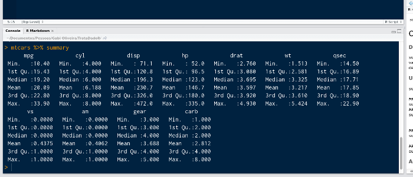

## Acessando o Help

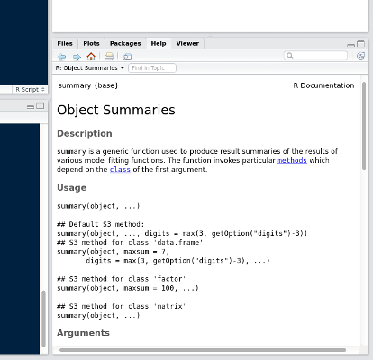

## Visualizando Gráficos

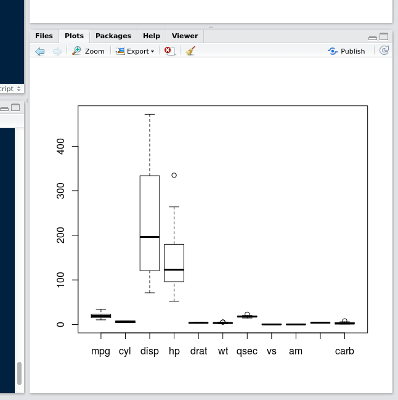

## Inspecionando Variáveis

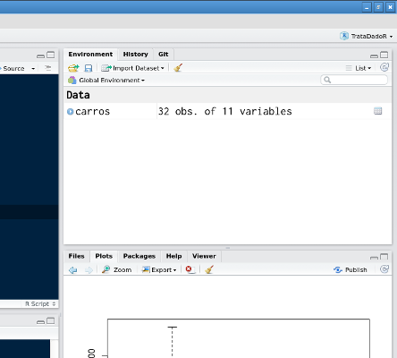

## Histórico de Comandos

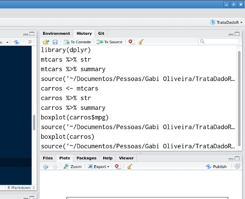

## Carregando Pacotes

[figure not shown]

## Instalação de pacotes com o R Studio

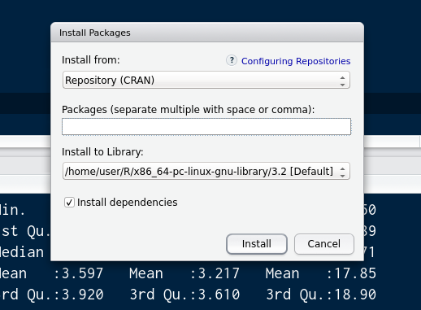

## Instalação de pacotes com o R Studio

Instale os pacotes

1. didáticos `swirl` e `Rcmdr`
2. de importação e exportação de dados `readxl`
3. de manuseio de dados `dplyr`, `tidyr`, `reshape`, `reshape2`, `lubridate`, `magrittr` e `car`

## Tópicos Extra

## *R Markdown*

Entre no menu `File > New File > R Markdown...` e crie um arquivo de apresentação (em *Presentation*) ou um documento PDF ou HTML (em *Document*).

Eu criei esta apresentação com o R Markdown no R Studio.

## *R Markdown*

[figure not shown]

## *Controle de Versão com Git*

O seu programa funcionava direito com certeza até anteontem.

Ontem você fez algumas edições e o seu programa começou a se comportar estranho.

Você continuou editando e hoje, com certeza, o programa está funcionando errado.

Como reverter o seu programa de volta para a versão de anteontem, que funcionava direitinho, se ela já foi sobrescrita vez após vez ao longo de dois últimos dias?

Resposta: **Sistema de Controle de Versão!!!**

https://git-scm.com/